# Analyse de données agroalimentaire

##### iv. Variable `Colo`: la coloration de la chair à sa réception

```r
colo2020=(table(mydata2020$Colo)/length(mydata2020$Colo))*100
colo2021=(table(mydata2021$Colo)/length(mydata2021$Colo))*100
colopr=round(rbind(colo2020,colo2021),2)

colnames(colopr)=c("1","1.5","2","2.5","3")
rownames(colopr)=c("Année 2020","Année 2021")
colopr
```

```
##               1   1.5     2   2.5    3
## Année 2020 10.2 14.29 69.39  4.08 2.04
## Année 2021  0.0 21.88 57.81 12.50 7.81
```

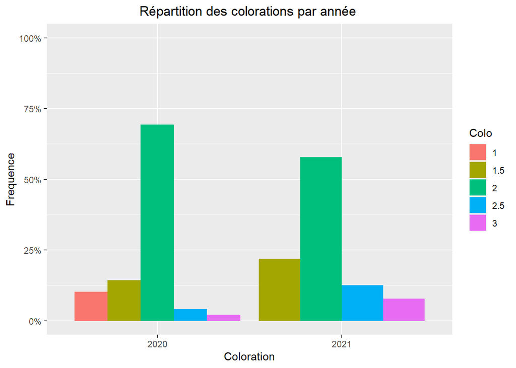

```r
freqColo <- mydata %>%   group_by(Annee,Colo)  %>% summarise(n=n(),.groups = "drop_last")   %>% mutate(freq=n/sum(n))


ggplot(freqColo,  aes(x=Annee, fill = Colo
                 , group = Colo)) + geom_bar(aes(y=freq), stat="identity", position = "dodge")+ coord_cartesian(ylim=c(0,1))+
  xlab("Coloration") +
  ylab("Frequence")+ scale_y_continuous(labels = percent)+
  ggtitle("Répartition des colorations par année ")+theme(
  plot.title = element_text(hjust = 0.5))
```

Pour les deux années, la coloration 2 est largement dominante par rapport aux autres colorations. En 2021 on constate une absence de la coloration 1.

##### v. Variable `Taches`: Présence ou non de taches d’eau dans la chair

```r
Tache2020=(table(mydata2020$Taches)/length(mydata2020$Taches))*100
Tache2021=(table(mydata2021$Taches)/length(mydata2021$Taches))*100
Tachepr=round(rbind(Tache2020,Tache2021),2)
colnames(Tachepr)=c("Abscence %", "Presence %")
rownames(Tachepr)=c("Année 2020","Année 2021")
Tachepr
```

```
##            Abscence % Presence %
## Année 2020      95.92       4.08
## Année 2021      90.62       9.38
```

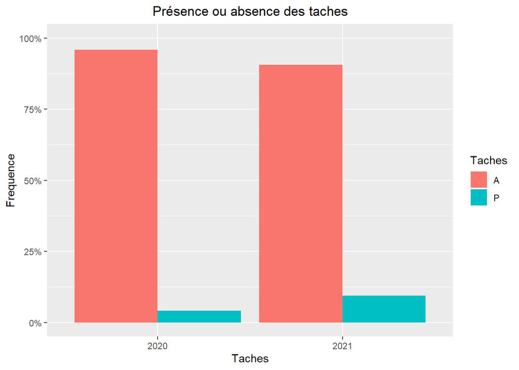

```r
#multi=Tachepr[2,2]/Tachepr[1,2] #calcul du  quotient de proportion entre les taches 2020 et 2021
#multi

freqTaches <- mydata %>%   group_by(Annee,Taches)  %>% summarise(n=n(),.groups = "drop_last")   %>% mutate(freq=n/sum(n))


ggplot(freqTaches,  aes(x=Annee, fill = Taches
                 , group = Taches)) + geom_bar(aes(y=freq), stat="identity", position = "dodge")+ coord_cartesian(ylim=c(0,1))+
  ylab("Frequence")+
  xlab("Taches") +scale_y_continuous(labels = percent)+
  ggtitle("Présence ou absence des taches")+theme(plot.title = element_text(hjust = 0.5))
```

Une analyse comparative par année indique que plus de 90% des fruits n’avaient pas de tâches. La présence de tâches en 2021 est 2.30 fois supérieur à celui obtenue en 2020.

##### vi. Variable `Homo_7j`:

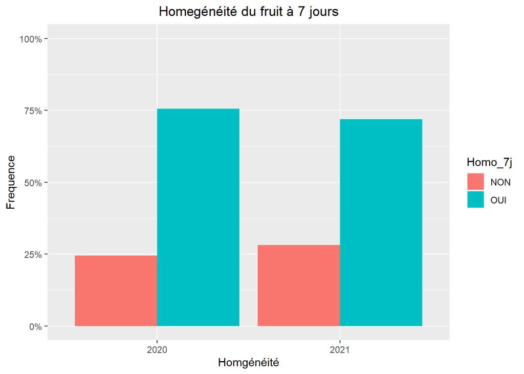

Le graphique nous montre que durant ces deux années la majorité du fruit sont homogène à 7 jours. Pendant la première année, le taux de fruits homogène était de 75.5% contre 24.49% de fruits non homogène. En 2021, on a une homogénéité de 71.8%.

##### vii. Variable `Conf_7j`

```r
mydata$Conf_7j = factor(mydata$Conf_7j,c("NC","C","TC"))
pr2020=(table(mydata2020$Conf_7j)/length(mydata2020$Conf_7j))*100
pr2021=(table(mydata2021$Conf_7j)/length(mydata2021$Conf_7j))*100
Conf=round(rbind(pr2020,pr2021),2)
colnames(Conf)=c("Conforme en %", "Non Conforme en %" ,"Très Conforme en %")
rownames(Conf)=c("Année 2020","Année 2021")
Conf
```

```
##            Conforme en % Non Conforme en % Très Conforme en %
## Année 2020         61.22             32.65               6.12
## Année 2021         71.88             25.00               3.12
```

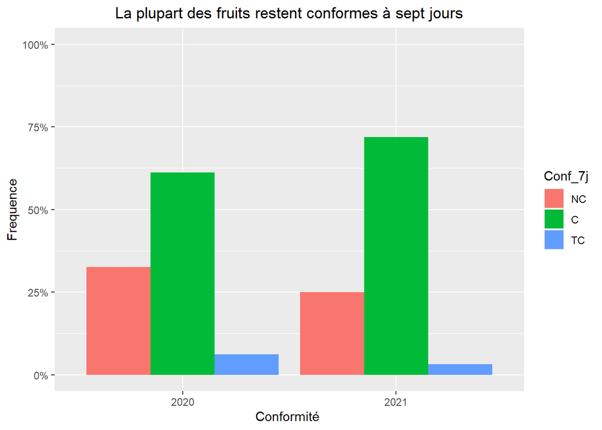

```r
t=((pr2021[1]-pr2020[1])/pr2020[1])*100
Taux_evolution=round(t,2)

freqConf_7j <- mydata %>%   group_by(Annee,Conf_7j)  %>% summarise(n=n(),.groups = "drop_last")   %>% mutate(freq=n/sum(n))


ggplot(freqConf_7j,  aes(x=Annee, fill = Conf_7j
                 , group = Conf_7j)) + geom_bar(aes(y=freq), stat="identity", position = "dodge")+ coord_cartesian(ylim=c(0,1))+
  ylab("Frequence")+
  xlab("Conformité ") +scale_y_continuous(labels = percent)+
  ggtitle("La plupart des fruits restent conformes à sept jours")+theme(plot.title = element_text(hjust = 0.5))
```

Sur les deux ans la majorité des fruits réceptionnés sont conformes. On constate une augmentation de la conformité des fruits de près de 17% en 2021. La proportion de fruits non conforme en 2020 reste supérieure à la proportion de fruit en 2021.

##### viii. Variable `carac_7j`:

```r
pr2020=(table(mydata2020$reco_caract_7j)/length(mydata2020$reco_caract_7j))*100
pr2021=(table(mydata2021$reco_caract_7j)/length(mydata2021$reco_caract_7j))*100
vi=round(rbind(pr2020,pr2021),2)

Carac=vi[,-c(3:4)]
colnames(Carac)=c("bp en %", "bru en %","lev en %")
rownames(Carac)=c("Année 2020","Année 2021")
Carac
```

```
##            bp en % bru en % lev en %
## Année 2020   14.29    20.41    65.31
## Année 2021    6.25    56.25    37.50
```

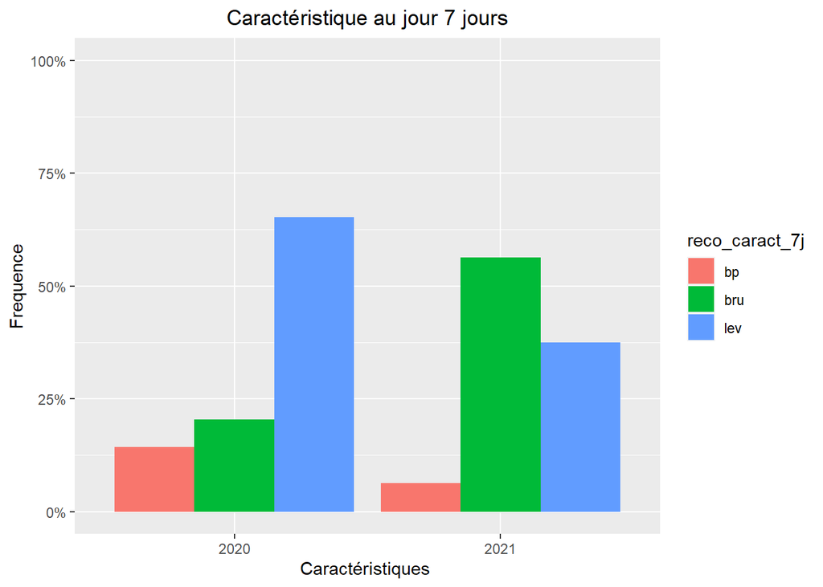

```r
freqreco_caract_7j <- mydata %>%   group_by(Annee,reco_caract_7j)  %>% summarise(n=n(),.groups = "drop_last")   %>% mutate(freq=n/sum(n))


ggplot(freqreco_caract_7j,  aes(x=Annee, fill = reco_caract_7j
                 , group = reco_caract_7j)) + geom_bar(aes(y=freq), stat="identity", position = "dodge")+ coord_cartesian(ylim=c(0,1))+
  ylab("Frequence")+
  xlab("Caractéristiques ") +scale_y_continuous(labels = percent)+
  ggtitle("Caractéristique au jour 7 jours")+theme(plot.title = element_text(hjust = 0.5))
```

##### ix. Variable `Colo_7j`

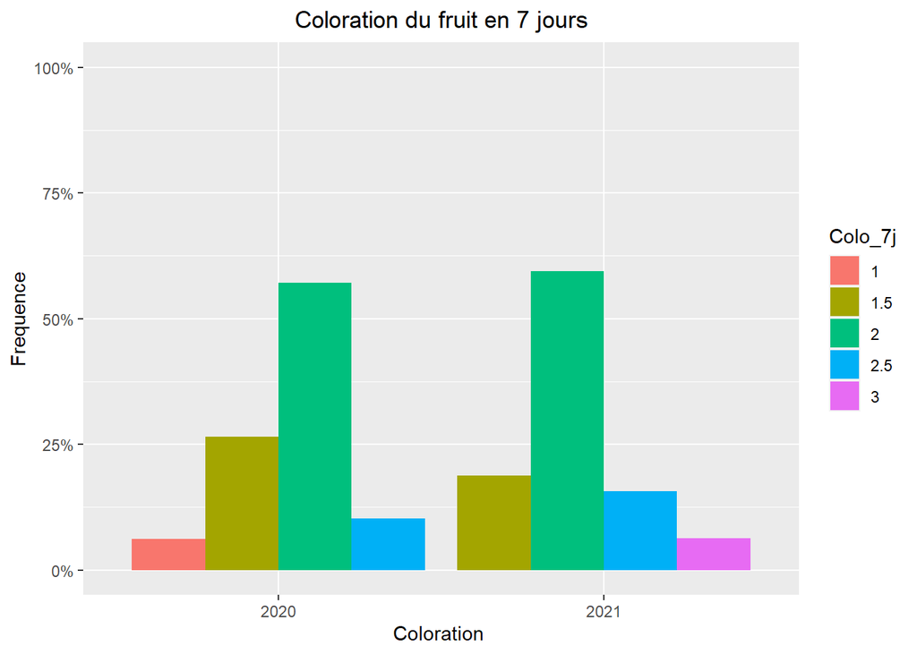

```r
freqColo_7j <- mydata %>%   group_by(Annee,Colo_7j)  %>% summarise(n=n(),.groups = "drop_last")   %>% mutate(freq=n/sum(n))


ggplot(freqColo_7j,  aes(x=Annee, fill = Colo_7j
                 , group = Colo_7j)) + geom_bar(aes(y=freq), stat="identity", position = "dodge")+ coord_cartesian(ylim=c(0,1))+
  ylab("Frequence")+
  xlab("Coloration ") +scale_y_continuous(labels = percent)+
  ggtitle("Coloration du fruit en 7 jours")+theme(plot.title = element_text(hjust = 0.5))
```

On constate une absence de fruit ayant la coloration 3 en 2020 et une absence de fruit ayant la coloration 1 en 2021. La grande majorité des fruits avaient la coloration 2. La proportion de fruit prenant une coloration 2 évolue peu de 2020 à 2021.

#### c. Variables quantitatives continues

##### i. Variable `Hauteur`:

```r
summary(mydata2020$Hauteur)
```

```
##    Min. 1st Qu.  Median    Mean 3rd Qu.    Max.
##    14.5    17.0    18.0    17.6    18.5    20.0
```

```r
summary(mydata2021$Hauteur)
```

```
##    Min. 1st Qu.  Median    Mean 3rd Qu.    Max.
##   16.00   17.00   17.50   17.74   18.50   20.00
```

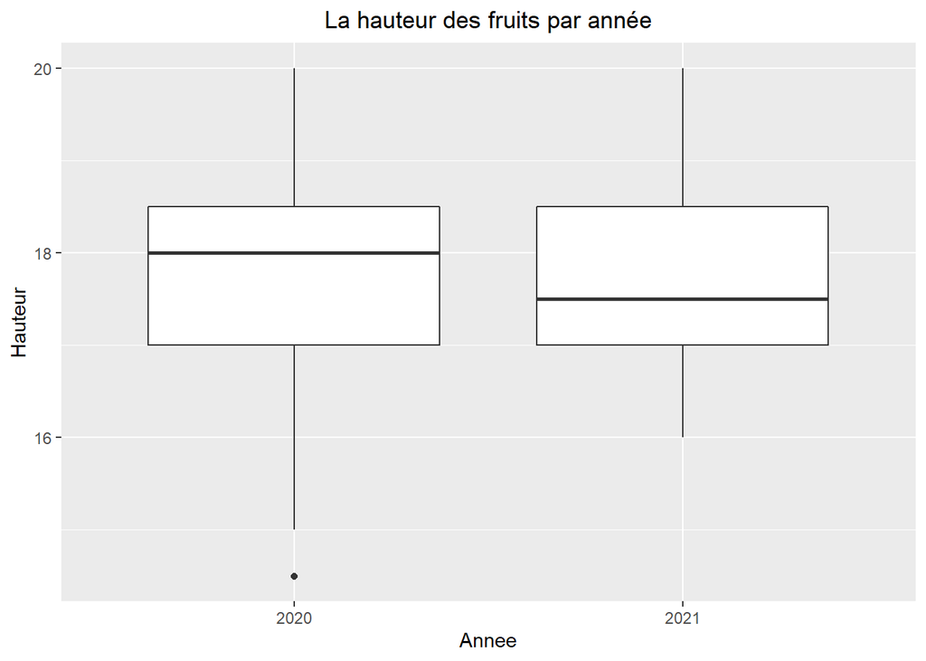

```r
ggplot(mydata, aes(x=Annee, y=Hauteur)) +
  geom_boxplot()+ggtitle("La hauteur des fruits par année")+theme(
  plot.title = element_text(hjust = 0.5))
```

Globalement, en 2020 la dispersion de la hauteur des fruits est plus grande pour celle inférieure au deuxième quartile 18, par contre en 2021 la dispersion de la hauteur des fruits est plus grande pour celle supérieur au deuxième quartile 17.5.

##### ii. Variable `Diametre`

```
##    Min. 1st Qu.  Median    Mean 3rd Qu.    Max.
##   11.00   12.00   12.50   12.53   13.00   14.30
```

```
##    Min. 1st Qu.  Median    Mean 3rd Qu.    Max.
##   11.00   11.50   12.00   12.06   12.50   14.00
```

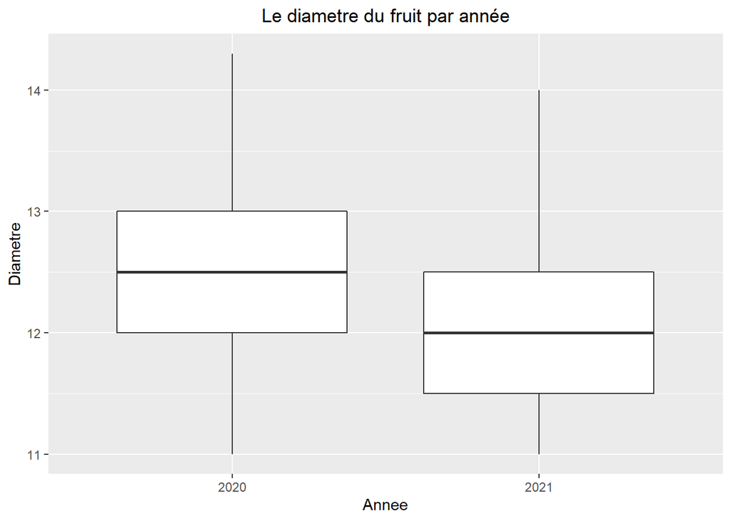

Le diamètre des fruits en centimètres est compris entre 11 et 14.3. En 2020, 25% des diamètres ont des valeurs inférieures à 12, 50% des diamètres ont en dessous de 12.5 et les 75% des diamètres des fruits sont en dessous de 13.

En 2021, 25% des de la Diamètre ont de valeurs inférieures à 11.5, 50% des valeurs sont en dessous de 12 et les 75% des diamètres sont en dessous de 12.5. On remarque que les deux boites à moustaches n’ont pas la même allure avec le positionnement des diagrammes qui diffèrent.

Les dispersions des valeurs semblent différer. Notamment les médianes qui sont représentées par les traits horizontaux dans les boites, ne sont pas au meme niveau.

##### iii. Variable `Rendement`:

```r
summary(mydata2020$Rendement)
```

```
##    Min. 1st Qu.  Median    Mean 3rd Qu.    Max.
##  0.2800  0.4300  0.4500  0.4478  0.4900  0.5500
```

```r
summary(mydata2021$Rendement)
```

```
##    Min. 1st Qu.  Median    Mean 3rd Qu.    Max.
##  0.3500  0.4500  0.4700  0.4805  0.5000  0.6500
```

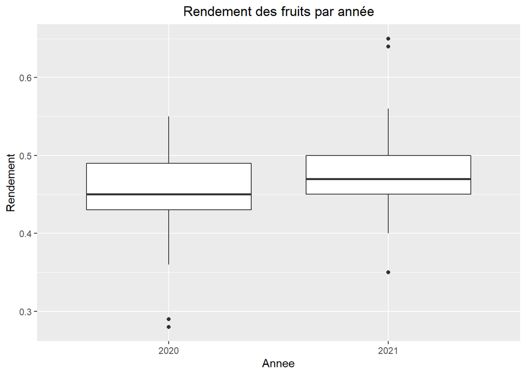

```r
mydata1 = rbind(mydata2020,mydata2021)
ggplot(mydata1, aes(x=Annee, y=Rendement)) +
  geom_boxplot()+ggtitle("Rendement des fruits par année")+theme(
  plot.title = element_text(hjust = 0.5))
```

##### iv. Variable `Productivité`

```
##    Min. 1st Qu.  Median    Mean 3rd Qu.    Max.
##    65.0    92.4   105.0   110.8   127.8   203.9
```

```
##    Min. 1st Qu.  Median    Mean 3rd Qu.    Max.
##    74.8   114.9   126.8   129.2   139.8   188.2
```

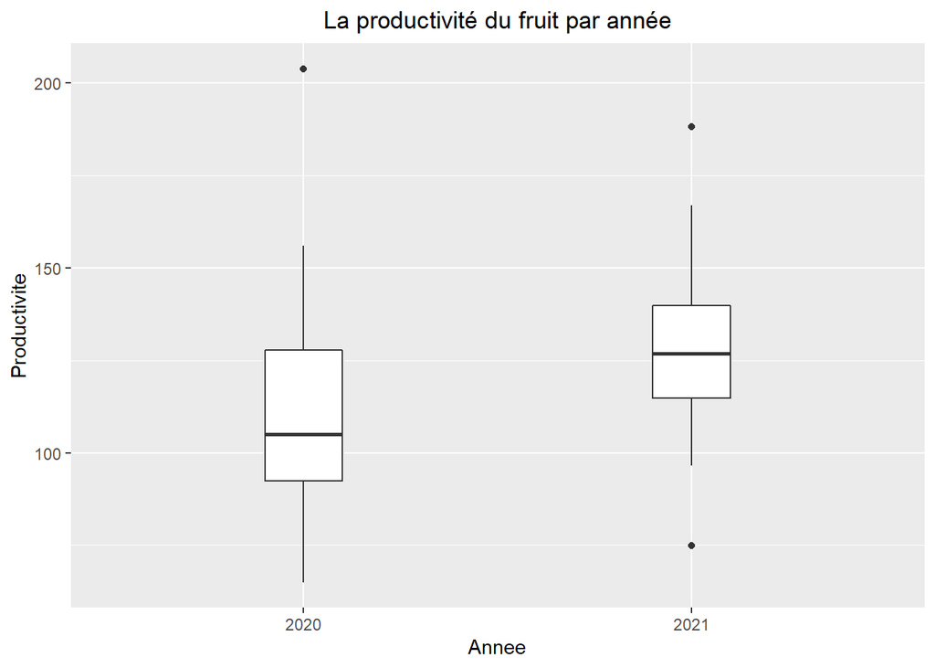

En 2020, 25% des valeurs de la productivité sont inférieures à 92.4, 50% des valeurs sont en dessous de 105 et les 75% des productivités des fruits sont en dessous de 127.8.

En 2021, 25% des de la productivité est de valeur inférieure à 114.9, 50% des valeurs est en dessous de 126.8 et 75% de la productivité est en dessous de 139.8.

On remarque que les deux boites à moustache n’ont pas la même allure avec le positionnement des diagrammes qui diffèrent. Les dispersions des valeurs semblent différer. De plus les médianes qui sont représentées par les traits horizontaux dans les boites à moustache ne sont pas au meme niveau.

##### v. Variable `Forme`

La forme c’est rapport de la hauteur sur le diamètre. Elle dépend de la hauteur et du diamètre des fruits et elle varie entre 1.15 et 1.74.

```
##    Min. 1st Qu.  Median    Mean 3rd Qu.    Max.
##   1.150   1.330   1.380   1.407   1.470   1.740
```

```
##    Min. 1st Qu.  Median    Mean 3rd Qu.    Max.
##   1.250   1.400   1.480   1.474   1.542   1.670
```

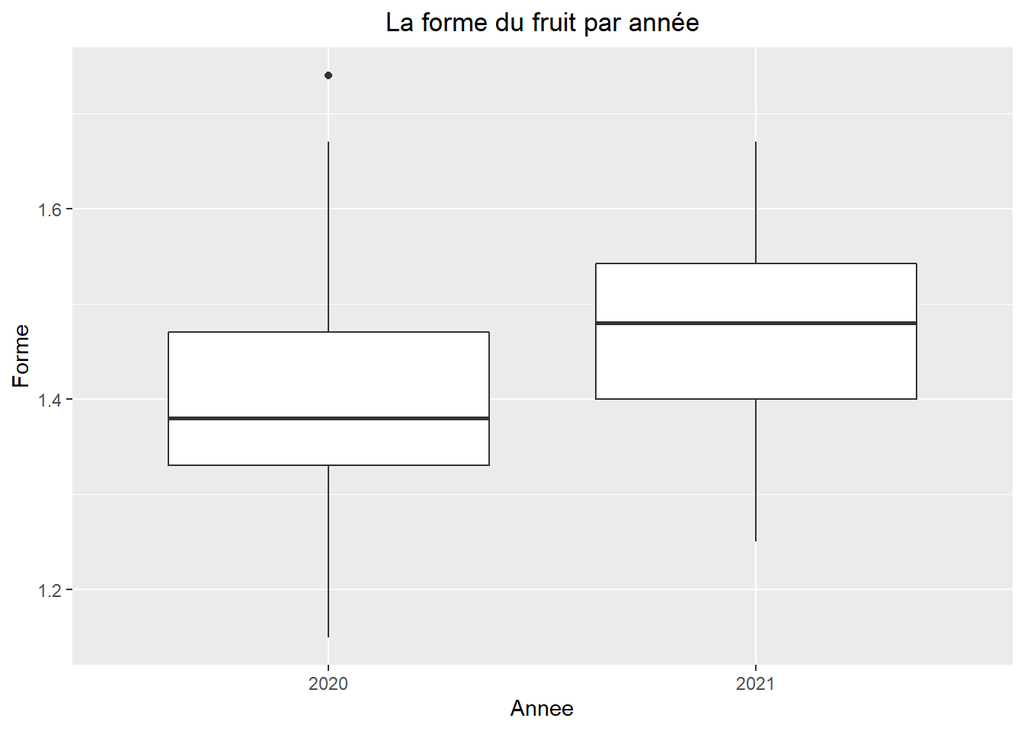

Dans le graphique ci dessus, on remarque que le positionnement des deux boites à moustache diffèrent selon les années. De plus les médianes qui sont représentées par les traits horizontaux dans les boites à moustaches, ne sont pas au meme niveaux. On note la présence d’une valeur aberrante en 2020.

##### vi. Variable `Brix`

C’est le taux de sucre en pourcentage

```r
summary(mydata2020$Brix)
```

```
##    Min. 1st Qu.  Median    Mean 3rd Qu.    Max.
##   12.00   14.00   15.00   14.74   16.00   18.00
```

```r
summary(mydata2021$Brix)
```

```
##    Min. 1st Qu.  Median    Mean 3rd Qu.    Max.
##   10.70   13.00   14.20   14.26   15.50   19.60
```

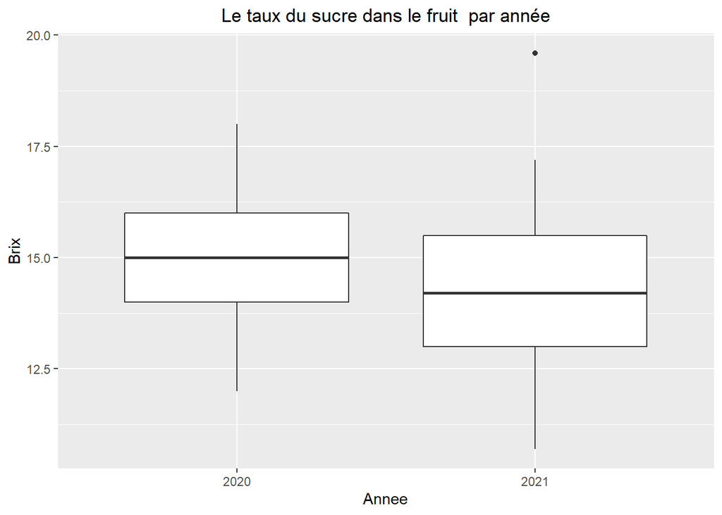

```r
ggplot(mydata, aes(x=Annee, y=Brix)) +
  geom_boxplot()+ggtitle("Le taux du sucre dans le fruit  par année")+theme(
  plot.title = element_text(hjust = 0.5))
```

Le centre de la distribution du taux de sucre en 2021 est plus petit que la distribution en 2020. La distribution des données en 2021 est asymétrique car la portion en bas de la moustache est plus longue que du côté haut. On constate la présence de valeur aberrante en 2021.

#### d. Variables quantitatives discrètes

##### i. Variable `Note_recep` :

Cette variable représente la note à la réception de la palette. Elle varie entre 1 et 5. Elle permet de juger de la recevabilité du produit.

```r
(table(mydata2020$reco_Note_recep)/length(mydata2020$reco_Note_recep))*100
```

```
##
##         2         3       3.5       3.8         4         5
##  2.040816 28.571429  0.000000  0.000000 63.265306  6.122449
```

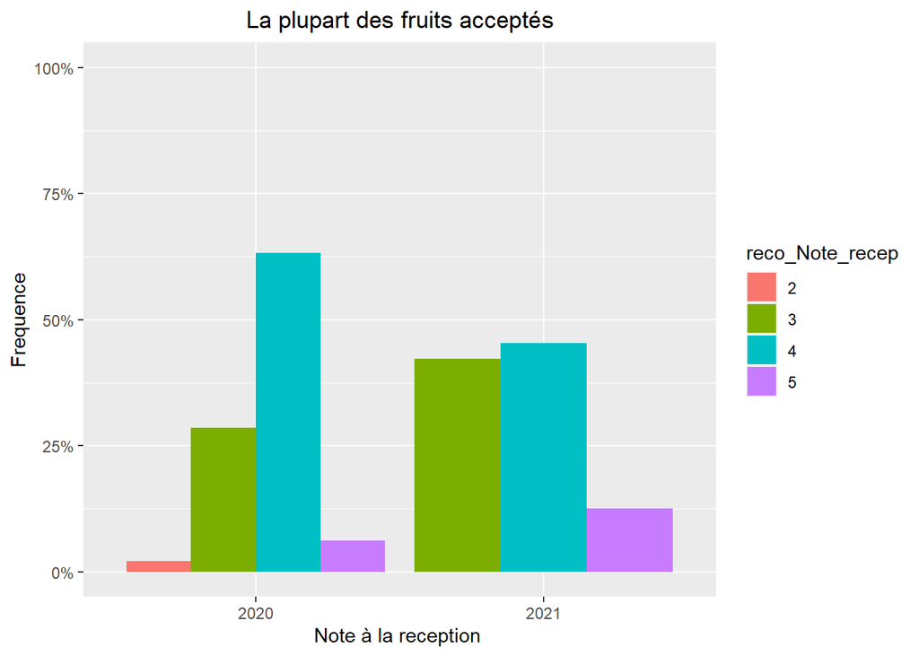

```r
freqreco_Note_recep <- mydata %>%   group_by(Annee,reco_Note_recep)  %>% summarise(n=n(),.groups = "drop_last")   %>% mutate(freq=n/sum(n))


ggplot(freqreco_Note_recep,  aes(x=Annee, fill = reco_Note_recep
                 , group = reco_Note_recep)) + geom_bar(aes(y=freq), stat="identity", position = "dodge")+ coord_cartesian(ylim=c(0,1))+
  ylab("Frequence")+
  xlab("Note à la reception ") +scale_y_continuous(labels = percent)+
  ggtitle("La plupart des fruits acceptés")+theme(plot.title = element_text(hjust = 0.5))
```

Un produit n’est accepté si et seulement cette note est supérieure ou égale à 3. Tous les fruits réceptionnés en 2021 sont acceptables, près de 2% des fruits ont été jugé inacceptable en 2020.

##### ii. Variable `delais_transf` :

Elle représente le délai entre la réception et la transformation en nombre de jours.

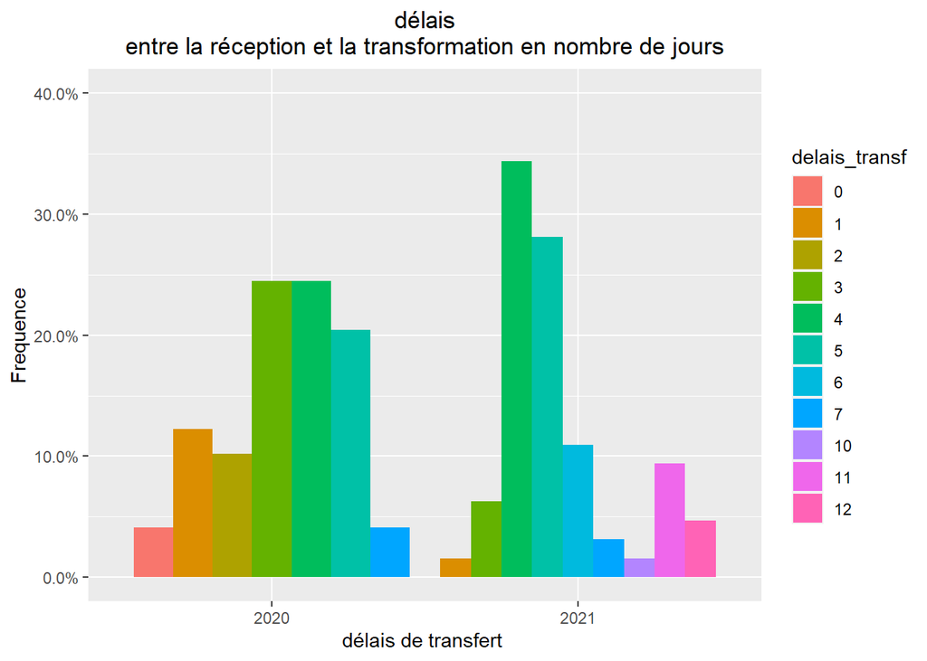

Pour l’année 2021 : le nombre de jours max avant transformation est de 12 jours et la majorité des fruits est transformée en 4-5 jours.

#### e. Variables quantitatives continues

## III. Etude de la normalité et Tests de comparaison :

#### 1. Etude de la normalité

un test de normalité Un test de shapiro-wilk qui nous permettra d’avoir une position plus tranchée sur la normalité des données. Si la p-value obtenue est supérieur à 0.05 on peut admettre que les données suivent une loi normale.

```r
shapiro.test(mydata$Brix[mydata$Annee==2020])$p.value
```

```
## [1] 0.08420841
```

```r
shapiro.test(mydata$Brix[mydata$Annee==2021])$p.value
```

```
## [1] 0.09875654
```

Ainsi on pour l’année 2020 une p-value = 0.08420841. Comme p-value est > a 0.05, on peut admettre que le taux de sucre pour l’année 2020 suit une loi normale. De façon similaire le taux de sucre pour l’année 2021 suit une loi normale car on a une p-value=0.09875654 qui est supérieur à 0.05. L’hypothèse de normalité étant vérifiée, on peut comparer les distributions 2020 et 2021 avec le test de Student.

```r
shapiro.test(mydata$Hauteur[mydata$Annee==2020])$p.value
```

```
## [1] 0.2554412
```

```r
shapiro.test(mydata$Hauteur[mydata$Annee==2021])$p.value
```

```
## [1] 0.0004889163
```

```r
shapiro.test(mydata$Diametre[mydata$Annee==2020])$p.value
```

```
## [1] 0.02046019
```

```r
shapiro.test(mydata$Diametre[mydata$Annee==2021])$p.value
```

```
## [1] 0.0002104291
```

```r
shapiro.test(mydata$Age_recep[mydata$Annee==2020])$p.value
```

```
## [1] 0.008720714
```

```r
shapiro.test(mydata$Age_recep[mydata$Annee==2021])$p.value
```

```
## [1] 1.457076e-07
```

Comme p-value est inférieur à 0.05 pour les deux échantillons on poursuivra avec un test de Mann-Whitney pour comparer la distribution des données.

```r
shapiro.test(mydata$Rendement[mydata$Annee==2020])$p.value
```

```
## [1] 0.0001204789
```

```r
shapiro.test(mydata$Rendement[mydata$Annee==2021])$p.value
```

```
## [1] 3.365752e-05
```

Comme p-value est inférieure à 0.05 pour les deux échantillons on poursuivra avec un test de Mann-Whitney pour comparer la distribution des données.

#### 2. Test de comparaison de moyennes pour certaines variables quantitatives

Sous l’hypothèse de normalité, nous utiliserons le test de student pour la comparaison des moyennes. En dehors de cette condition, nous ferons un test non paramétrique comme le test de Mann-Whitney. Le test U de Mann-Whitney (aussi appelé test de la somme des rangs de Wilcoxon ou plus simplement test de Wilcoxon) sert à tester l’hypothèse selon laquelle la distribution des données est la même pour deux groupes.

Lorsque la p-value est supérieur a 5%, on ne peut pas prétendre à une différence significative entre les 2 années.

```r
b = c(t.test(mydata$Brix[mydata$Annee==2020],mydata$Brix[mydata$Annee==2021])$p.value,
      wilcox.test(mydata$Hauteur[mydata$Annee==2020],mydata$Hauteur[mydata$Annee==2021])$p.value,
      wilcox.test(mydata$Diametre[mydata$Annee==2020],mydata$Diametre[mydata$Annee==2021])$p.value,
      wilcox.test(mydata$Age_recep[mydata$Annee==2020],mydata$Age_recep[mydata$Annee==2021])$p.value,
      wilcox.test(mydata$Rendement[mydata$Annee==2020],mydata$Rendement[mydata$Annee==2021])$p.value)

b2=as.numeric(b)
a =c("Brix", "Hauteur", "Diametre", "Age_recep", "Rendement")


ddd=data.frame(a,round(b,4))
colnames(ddd)=c("Variables","P-value")
ddd
```

```
##   Variables P-value
## 1      Brix  0.1310
## 2   Hauteur  0.7868
## 3  Diametre  0.0003
## 4 Age_recep  0.0217
## 5 Rendement  0.1018
```

On peut donc affirmer avec un faible risque de se tromper que le `Brix`, la `Hauteur` et le `Rendement` qu’il n’y a pas une différence significative entre les moyennes données 2021. Pour les autres variables, la p-value est inférieure à 5%. On dira qu’il y’a une différence significative entre les moyennes données 2020 et 2021.

#### 3. Comparaison par année 2020 et 2021 pour les variables qualitatives (ou quanti discretes)

#### i. Variable Discrete `Note_Recep` :

Afin d’avoir un résultat significatif, nous allons recoder les données comme suit : - Pour 2020 : Les notes 2 et 5 seront affectées aux notes 3 et 4 respectivement - Pour 2021 : Les notes 3.5, 3.8 et 5 seront affectées aux notes 3, 4 et 4 respectivement.

```
##
##  3  4
## 15 34
```

```
##
##  3  4
## 27 37
```

```
##
##  Chi-squared test for given probabilities
##
## data:  TableauContegence2021
## X-squared = 4.5268, df = 1, p-value = 0.03337
```

```
##
##  3  4
## 27 37
```

```
##    3    4
## 19.2 44.8
```

Le resultat du test de chi-deux nous donne une p-value inférieur a 5% (p-value = 0.03337), donc on peut affirmer avec un faible risque de se tromper qu’il y’a une différence significative entre les distributions de 2020 et 2021 concernant la Note à la réception.

#### ii. Variable Qualitative : `Taches`

```r
table(mydata2020$Taches);
```

```
##
##  A  P
## 47  2
```

```r
table(mydata2021$Taches)
```

```
##
##  A  P
## 58  6
```

Il faut un effectif supérieur 5 pour que le test détecte des différences pratiques avec une probabilité élevée.

On ne peut donc pas trancher quant à la différence des distributions des Taches entre 2020 et 2021.

#### iii. Variable Qualitative : `Conf_7j`

```r
mydata2020$reco_Conf_7j<-mydata2020$Conf_7j
mydata2020$reco_Conf_7j[mydata2020$reco_Conf_7j=="TC"]<-"C"


mydata2021$reco_Conf_7j<-mydata2021$Conf_7j
mydata2021$reco_Conf_7j[mydata2021$reco_Conf_7j=="TC"]<-"C"

mydata2020$reco_Conf_7j=as.character(mydata2020$reco_Conf_7j)
mydata2021$reco_Conf_7j=as.character(mydata2021$reco_Conf_7j)

table(mydata2020$reco_Conf_7j);table(mydata2021$reco_Conf_7j)
```

```
##
##  C NC
## 33 16
```

```
##
##  C NC
## 48 16
```

```r
resConf <- chisq.test(x=table(mydata$Taches), p=c(0.67,0.33))
resConf
```

```
##
##  Chi-squared test for given probabilities
##
## data:  table(mydata$Taches)
## X-squared = 34.338, df = 1, p-value = 4.633e-09
```

## IV. Etude de la Liaison entre les variables qualitatives

Il y’a beaucoup de données manquantes pour 2020, nous travaillerons avec les données de 2021. Nous allons créer une base contenant toutes les variables qualitatives

```r
qlNA<-select(mydata2021,Colo,Taches,reco_Com_rec,Conf_7j,Colo_7j,Homo_7j,Carac_7j,Conf_8j,Colo_8j,Homo_8j,Carac_8j)
```

Dans cette section, on cherche à savoir comment la `couleur des fruits` et les `taches` sur ces derniers influent sur le `commentaire à la reception` ou la `note à la reception`. Ensuite on cherchera à voir comment l’`homogeneité` et le `caracteristique à 7j` influent sur le commentaire à 7j.

Pour cela nous procéderons comme suit : - visualiser les fréquences absolues(à travers un tableau de contingence par exemple) - tester le lien entre les 2 variables (liaison).

Pour tester le lien entre deux variables qualitatives on utilise le test du Khi-2 (test paramétrique), ou, si les conditions du diagnostic de régression ne sont pas remplies, on utilise le test exact de Fisher (test non-paramétrique). Ces deux tests sont pratique pour comparer des pourcentages.

Condition de validité du Khi-2 - Les valeurs de toutes les cases du tableau des effectifs doivent être supérieur à 5 - Les pourcentages ne sont pas trop proche de zéro ou de 100%

##### i. Liaison entre la coloration et le commentaire à la reception

Regardons le tableau de contingence des deux variables après avoir recoder afin de remplir les conditions pour un futur test de khi-deux

```r
#recodage avant le test de khi*deux pour avoir des classes avec n>5
mydata2021$reco_Colo2<-mydata2021$Colo
mydata2021$reco_Colo2[mydata2021$reco_Colo2=="1.5"]<-"2"
mydata2021$reco_Colo2[mydata2021$reco_Colo2=="3"]<-"2.5"

mydata2021$reco_Colo2=as.character(mydata2021$reco_Colo2)


Tc1<-table(mydata2021$reco_Colo2,qlNA$reco_Com_rec, deparse.level=2)

ColoCom_rec<-prop.table(Tc1)*100
lprop(ColoCom_rec)
```

```
##                      qlNA$reco_Com_rec
## mydata2021$reco_Colo2 A     E     D     Total
##              2         43.1  31.4  25.5 100.0
##              2.5        7.7  46.2  46.2 100.0
##              Ensemble  35.9  34.4  29.7 100.0
```

`Com_recep` : commentaire à la réception - A : acide, - D : doux, - E : équilibré

`Colo` : coloration de la chair à réception échelle 1/1,5/2/2,5/3

En 2021, Nous constatons que la majorité des fruits sont `acide` et appartiennent majoritairement à la coloration 2.

```r
mydata2021$reco_Colo2=as.character(mydata2021$reco_Colo2)
qlNA$reco_Com_rec=as.character(qlNA$reco_Com_rec)
qlNA$reco_Com_rec
```

```
##  [1] "D" "D" "E" "A" "A" "A" "A" "A" "A" "A" "E" "E" "A" "A" "A" "A" "D" "D" "D"
## [20] "A" "A" "A" "A" "E" "E" "E" "E" "E" "E" "D" "D" "D" "E" "D" "E" "E" "E" "D"
## [39] "D" "D" "E" "E" "A" "A" "E" "E" "A" "A" "A" "A" "D" "D" "E" "D" "E" "E" "E"
## [58] "E" "A" "A" "D" "D" "D" "D"
```

```r
chisq.test(mydata2021$reco_Colo2,qlNA$reco_Com_rec)
```

```
##
##  Pearson's Chi-squared test
##
## data:  mydata2021$reco_Colo2 and qlNA$reco_Com_rec
## X-squared = 5.7699, df = 2, p-value = 0.05586
```

##### ii. Liaison entre les taches et les commentaires à la reception

```
##            qlNA$reco_Com_rec
## qlNA$Taches A     D     E     Total
##    A         36.2  29.3  34.5 100.0
##    P         33.3  33.3  33.3 100.0
##    Ensemble  35.9  29.7  34.4 100.0
```

```
##
##  Pearson's Chi-squared test
##
## data:  qlNA$Taches and qlNA$reco_Com_rec
## X-squared = 0.044227, df = 2, p-value = 0.9781
```

##### iii. Liaison entre l’Homogénéité et les commentaires à la reception

```
##             qlNA$reco_Com_rec
## qlNA$Homo_7j A     D     E     Total
##     NON       38.9  22.2  38.9 100.0
##     OUI       34.8  32.6  32.6 100.0
##     Ensemble  35.9  29.7  34.4 100.0
```

```
##
##  Pearson's Chi-squared test
##
## data:  qlNA$Homo_7j and qlNA$reco_Com_rec
## X-squared = 0.67927, df = 2, p-value = 0.712
```

##### iv. Liaison entre du caractère à 7 jours et les commentaires à la reception

```
##              qlNA$reco_Com_rec
## qlNA$Carac_7j A     D     E     Total
##      bp        25.0   0.0  75.0 100.0
##      bru       44.4  33.3  22.2 100.0
##      fer       37.5  18.8  43.8 100.0
##      lb        22.2  33.3  44.4 100.0
##      lev       50.0  50.0   0.0 100.0
##      Ensemble  35.9  29.7  34.4 100.0
```

```
##
##  Pearson's Chi-squared test
##
## data:  qlNA$Carac_7j and qlNA$reco_Com_rec
## X-squared = 11.378, df = 8, p-value = 0.1812
```

#### 4. Etude de la Correlation entre les variables quantitatives

Pour l’étude des liaisons entre variables quantitatives, nous utiliserons le coefficient de corrélation de pearson ainsi que le niveau de significativité pour toutes les paires possibles de variables quantitatifs ainsi que le niveau de significativité qui est le résultat des tests de corrélation entre chaque paire de variables.

Les hypothèses du test sont les suivants:

H0 : “les caractères X et Y sont indépendants” contre H1 : “les caractères X et Y ne sont pas indépendants”.

Si la p-valeur obtenue du test de corrélation est inférieur à 0.05 on rejette H0 et ce réjet est hautement significatif. Ainsi on peut dire que X et Y on une dépendance.

```r
#création d'une base avec des données quantitatives
qtNA<-select(mydata2021, Rendement,Brix,Acidite,Hauteur,Diametre,Forme,Poids,Productivite,Age_7j,Age_8j,Age_recep)
#calcul du coefficient de corrélation
mcor<-cor(qtNA)
#mcor
#test de significativité de la correlation(p-value)
a=rcorr(as.matrix(qtNA),type="pearson")
```

##### i. Diagramme de corrélation : Corrélogramme

Dans le graphique ci dessous les corrélations positives sont affichées en bleu et les corrélations négatives en rouge. L’intensité de la couleur et la taille des cercles sont proportionnelles aux coefficients de corrélation. A droite du correllèlogramme, la légende de couleurs montre les coefficients de corrélation et les couleurs correspondantes.

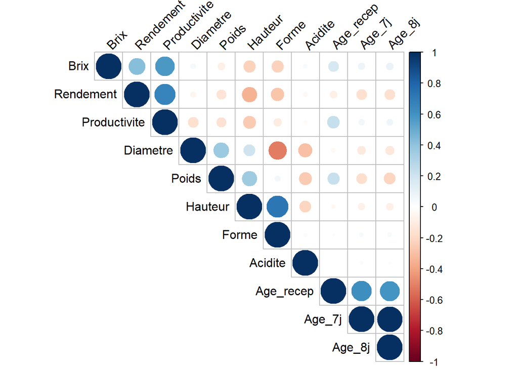

```r
#utiliser ggplot après
corrplot(mcor, type="upper", order="hclust", tl.col="black",tl.srt=45,insig="blank")
```

```r
#corrplot(mcor, type="upper", order="hclust", p.mat = a$P, sig.level = 0.05)
```

L’étude des corrélations de `Rendement` avec les autres variables nous indiquent l’existence d’une correlation faible et positive avec `Brix`et `Productivite`. Cette corrélation est hautement significative entre `Rendement` avec les variables `Brix` et `Productivite`.

La corrélation entre `Rendement` avec `Hauteur`et `Forme` est négative et faible. D’après la probabilité de test de corrélation l’existence d’un lien linéaire du `Rendement` est très significatif avec `Hauteur`, et significatif avec `Forme`.

Une liaison linéaire hautement significative est aussi observée entre `Brix` et les variables `Rendement`, `Productivite`.

quant à `Acidite`, elle est significativement corrélé au `Diametre`, `Poids`.

L’analyse de la corrélation entre `Hauteur` avec les autres variables montre l’existence d’une corrélation hautement significative entre `Hauteur` et `Forme`, Très significative entre `Hauteur` avec les variables `Rendement`, `Poids`. cette corrélation est significative entre `Hauteur` et `Productivite`.

La Corrélation entre `Diamètre` est négative et hautement significative avec `Forme`,positive et très significative avec `Poids`, négative et significative avec `Acidite`.

La corrélation entre `Forme` et les autres variables indiquent Une corrélation hautement significative avec `Hauteur` et `Diametre` cela est normale car la forme est le rapport de la hauteur sur le diamètre. Cette corrélation significative avec `Rendement`.

De même `Productivité` est corrélé positivement avec le `Rendement` et `Brix`, par contre cette corrélation est négative avec `Hauteur`. La corrélation est hautement significative entre `Productivite` avec `Rendement`, `Brix`, elle est significative avec `Hauteur`.

Certaines liaisons parmis nos variables sont liées à une dépendance temporelle. Par exemple la corrélation entre `Age_recep`, `Age_7j`et `Age_8j`. En effet `Age_7j` est égale à `Age_recep` plus sept jours et `Age_8j` est égale à `Age_7j` plus 1 jour cela explique la forte liaison de ces variables deux à deux.

Deux variables qui ont un coefficient de corrélation très élevés sont des variables qui on tendance à apporter la même information.

Pour résoudre ce problème nous allons construire des indicateurs qui résument beaucoup de variables, autrement dit à partir de l’ensemble des variables, nous chercherons à avoir une vision de l’ensemble des liaisons sans passer en revue chaque couple de variables.

L’analyse en composantes principales(ACP) est la méthode qui sera utilisée pour extraire et visualiser les informations importantes contenues dans une table de données multivariées. L’ACP synthétise cette information en seulement quelques nouvelles variables appelées composantes principales.

Ces nouvelles variables correspondent à une combinaison linéaire des variables originels. Le nombre de composantes principales est inférieur ou égal au nombre de variables d’origine.

## V. Analyse En Composante Principale et Typologie de fruit

L’objectif de cette partie du document est de considérer simultanément les caractéristiques des fruits afin de mettre en évidence:

Premièrement le profil des fruits qui se ressemble qui s’oppose, déterminer les principales dimensions de variabilité des fruits et déterminer les typologies de fruits qui ressemblent ou qui s’opposent.

Deuxièmement il s’agira de déterminer un bilan des liaisons entre les différentes variables.

Troisièmement associer à un groupe de fruit qui se ressemblent un profil particulier.

Pour la mise en oeuvre de l’ACP nous allons considérer les variables `Diamètre`, `Poids`, `Hauteur`, `Forme`, `Acidite`, et `Brix` comme variables actives car ces variables sont des caractéristiques quantitatives qui définissent mieux le profil de chaque fruit à partir d’elles d’autres variables telles que le rendement et la productivité ont été déterminés. Dans notre ACP nous considérerons comme variables quantitatives supplémentaires `Age_recep`, `Delais_transf`, `Age_7j`, `Note_8j`, `Note_7j`, `Age_8j`, `Rendement` et `Poductivite`.

```r
ACPdata<-select(mydata2021, Brix,Acidite,Hauteur,Diametre,Forme,Poids,Productivite,Rendement,delais_transf,Age_7j,Note_7j,Age_8j,Age_recep,Note_8j,Colo,Conf_7j, Com_rec,Note_recep)
res.pca=PCA(ACPdata,scale.unit=TRUE,quanti.sup = 7:14,quali.sup = 15:18, graph = FALSE)
#resultats des variables et individus pour l'acp
res.var<-get_pca_var(res.pca)
res.ind<-get_pca_ind(res.pca)
```

### Choix du nombre de dimensions

Pour déterminer le nombre de dimension à retenir nous allons utilisés la règle de Kaiser. Selon cette règle une valeur propre supérieur à 1 indique une composante qui représente plus de variance par rapport à une seule variable.

```r
#valeurs propres
val_propr=get_eigenvalue(res.pca)
val_propr
```

```
##        eigenvalue variance.percent cumulative.variance.percent
## Dim.1 1.997082465      33.28470775                    33.28471
## Dim.2 1.768838726      29.48064543                    62.76535
## Dim.3 0.885289116      14.75481859                    77.52017
## Dim.4 0.764695117      12.74491862                    90.26509
## Dim.5 0.582483854       9.70806424                    99.97315
## Dim.6 0.001610722       0.02684537                   100.00000
```

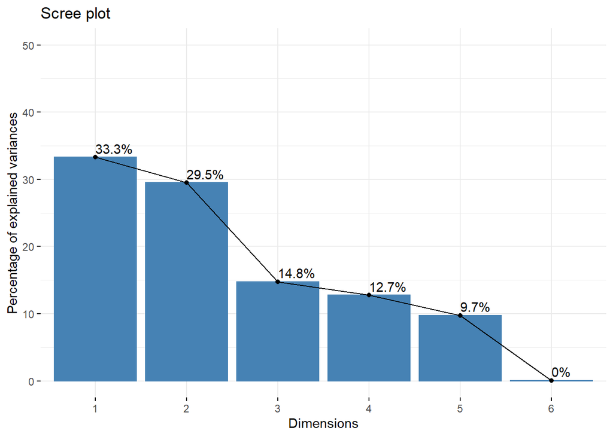

```r
#histogramme pour le coude
scree.plot=fviz_eig(res.pca,addlabels = T,ylim=c(0,50))
scree.plot
```

Ainsi on retiendra 2 dimensions cela est confirmé par le graphiques des valeurs propres qui nous indiques que les 2 premières dimensions expliques 62.77% des variations.

La première dimension exprime à elle seule 33.3% de la variabilité des données. La seconde dimension exprime 29.5% de l’inertie de la variabilité.

### 1. Etude de Variables

### 2. Contribution des variables aux deux principales dimensions

```r
contrib_attend=(1/6)*100
res.var$contrib[,1:2]
```

```
##               Dim.1        Dim.2
## Brix      9.3274763  1.367731648
## Acidite   6.1181238 16.105777781
## Hauteur  42.5845902  0.002559624
## Diametre  0.3556347 44.184259048
## Forme    27.9313112 22.149048208
## Poids    13.6828637 16.190623691
```

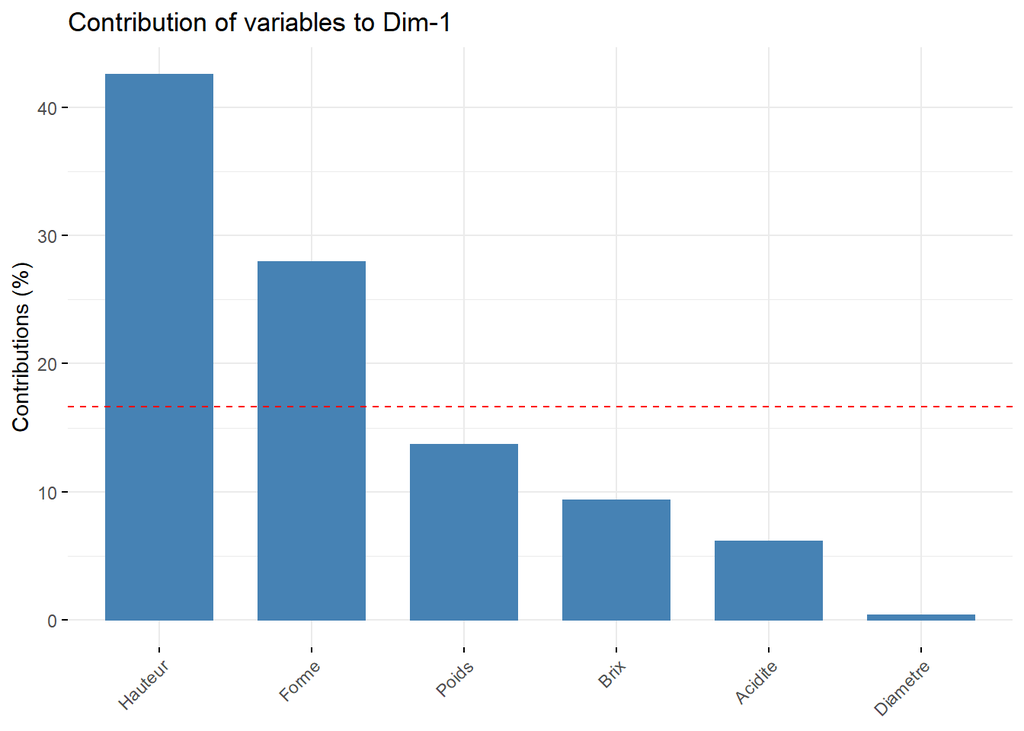

```r
# Contributions des variables à PC1
fviz_contrib(res.pca, choice = "var", axes = 1)
```

Le graphe de la contribution des variables nous montre que les variables qui contribuent le plus à la première dimension sont `Hauteur`(42.5%) et `Forme`(27%). La contribution des autres variables tels que `Brix`, `Acidite`, `Diamètre` et `Poids` sont inférieur à la contribution moyenne attendue sur cette dimension(16.6%) représente par la ligne en pointillé rouge.

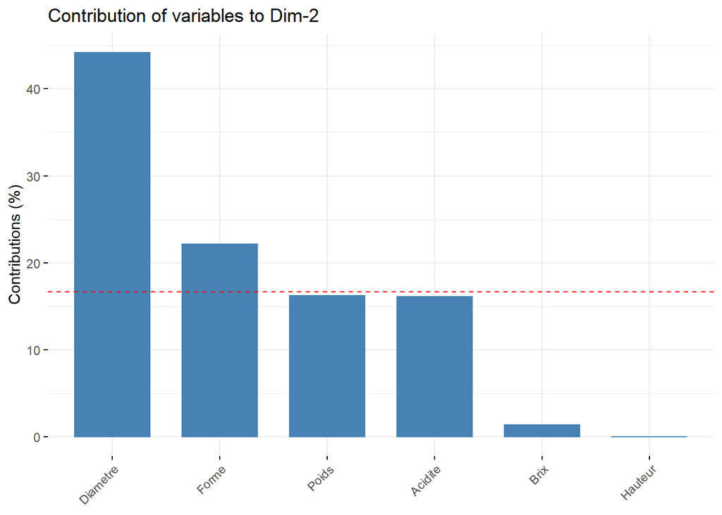

```r
# Contributions des variables à PC2
fviz_contrib(res.pca, choice = "var", axes = 2)
```

De même `Diamètre`(44.1%) et `Forme`(22.1%) contribuent plus à la deuxième dimension. `Acidite` (16.1%) et `Poids` (16.19%) on une contribution presque moyenne (16.6%). Quant à `Brix`(1.36%) et `Hauteur` (0.0025%) leurs contributions ne sont pas significatives.

### 3. Cercle de corrélation

Sur le cercle de corrélation, les variables en rouge sont les variables actives, celles en bleu sont les variables quantitatives supplémentaires.

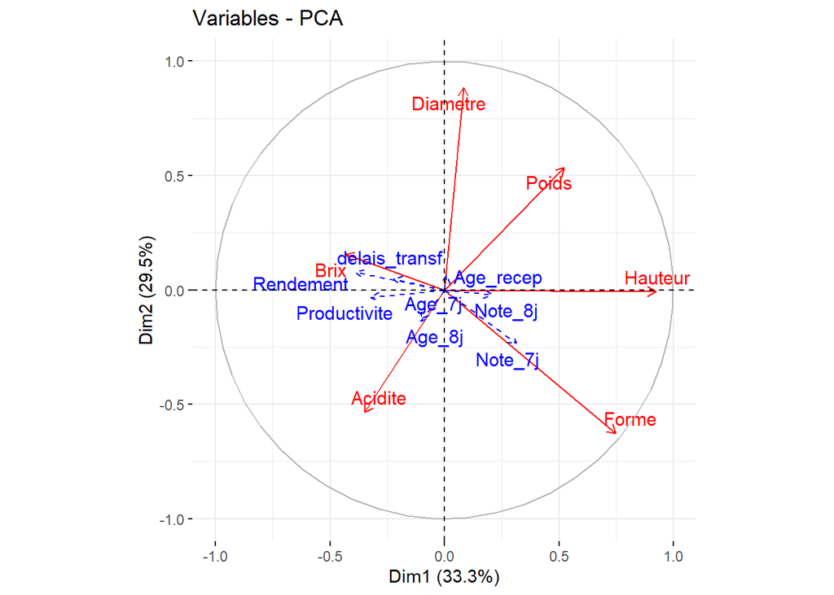

```r
#cercle de corrélation
fviz_pca_var(res.pca,col.var = "red",col.quanti.sup = "blue",repel = T)
```

A partir du graphique de corrélation des variables nous pouvons remarqués que les variables `Diametre`, `Hauteur` et `Forme` sont bien représentes sur les deux axes principaux.

La corrélation entre `Diamètre` et `Hauteur` est faible (r= 0.21), la corrélation entre `Diamètre` et `Forme` est négative (-0.51), la corrélation entre `Hauteur` et `Forme` est forte et positive (0.71).

En effet `Forme` est le rapport entre `Hauteur` et `Diamètre` ainsi une hauteur plus grande aura tendance à augmenter la forme du fruit et un grand diamètre divisera la forme du fruit cela entraînera donc une opposition de `Forme` et `Diamètre` sur la deuxième dimension.

Une description des dimensions est obtenue ci dessous

```r
#pour voir les variables qui décrivent chaque dimension
res.dim<-dimdesc(res.pca,axes = 1:2)
res.dim$Dim.1
```

```
## $quanti
##              correlation      p.value
## Hauteur        0.9221981 2.860340e-27
## Forme          0.7468677 1.378347e-12
## Poids          0.5227409 9.375126e-06
## Note_7j        0.3140877 1.148799e-02
## Productivite  -0.3215898 9.563010e-03
## Acidite       -0.3495482 4.637753e-03
## Rendement     -0.3874196 1.562733e-03
## Brix          -0.4315986 3.696791e-04
##
## $quali
##                R2    p.value
## Conf_7j 0.1078122 0.03082594
##
## $category
##              Estimate     p.value
## Conf_7j=C   0.4252633 0.012199422
## Conf_7j=NC -0.6516680 0.008262207
##
## attr(,"class")
## [1] "condes" "list"
```

```r
res.dim$Dim.2
```

```
## $quanti
##          correlation      p.value
## Diametre   0.8840522 3.764066e-22
## Poids      0.5351505 5.215891e-06
## Acidite   -0.5337464 5.580173e-06
## Forme     -0.6259241 3.186789e-08
##
## $category
##             Estimate    p.value
## Colo=Colo_3 1.083056 0.02129057
##
## attr(,"class")
## [1] "condes" "list"
```

La première dimension est plus liée aux variables `Hauteur` (0.92), `Forme` (0.74).

Avec un niveau de de confiance de 95%, la variable supplémentaire `Conf_7j` (p-valeur=0.03082594) caractérise la première dimension; les fruits Conformes (C) à 7 jours ont des coordonnées significativement plus élevées que la moyenne sur la première dimension tandis que les fruits non conformes (NC) à 7 jours ont des coordonnées inférieures à la moyenne.

La deuxième dimension est caractérisée par `Diamètre` (0.88) et `Forme` (-0.625). La modalité 3 de la coloration `Colo_3` (p-valeur=0.02) est aussi liée à la deuxième dimension avec un niveau de confiance de 95%.

### 4. Etude sur les Fruits

23 fruits contribuent fortement aux deux principales dimensions.

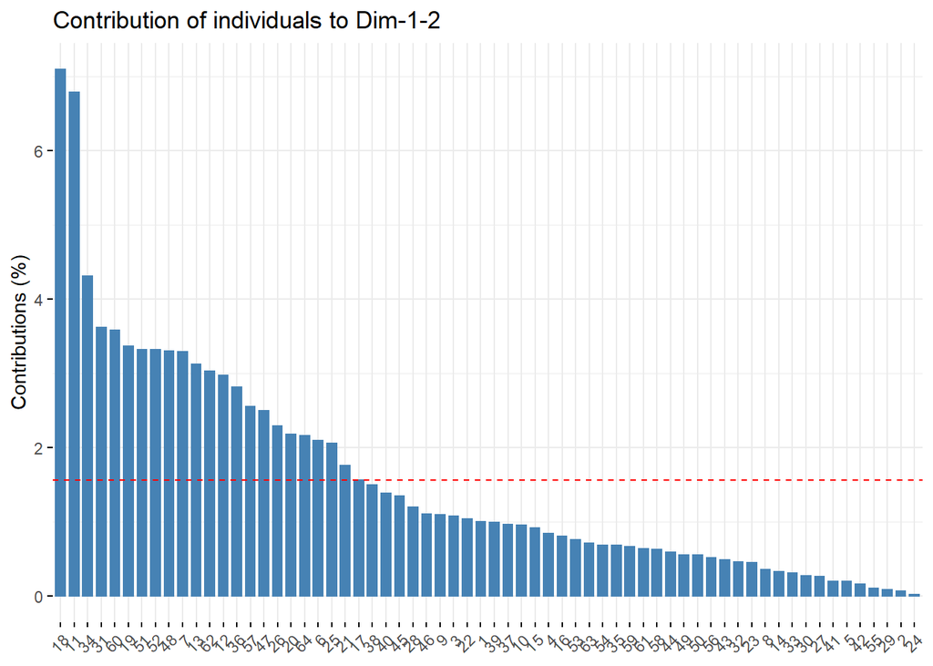

### 5. La représentation des fruits sur les deux principales est ci dessous:

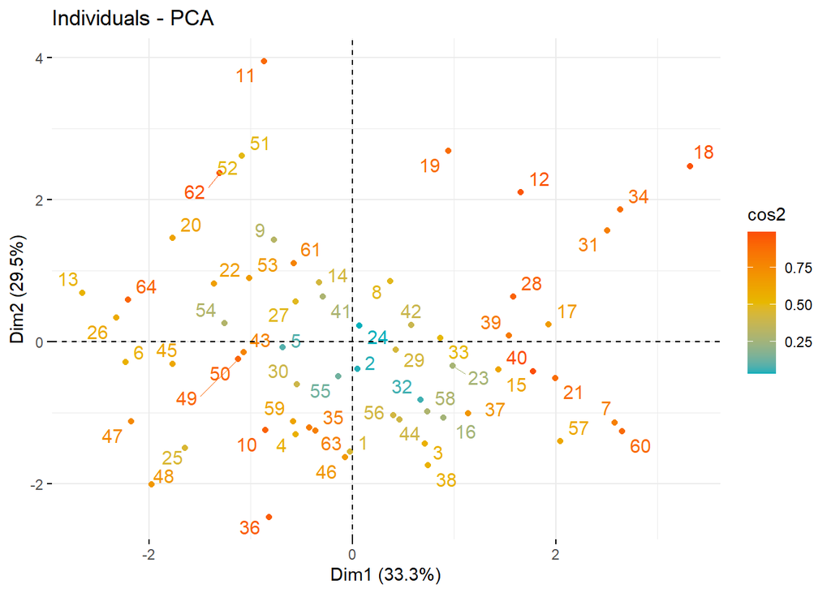

```r
fviz_pca_ind (res.pca, col.ind = "cos2",
             gradient.cols = c("#00AFBB", "#E7B800", "#FC4E07"),
             repel = TRUE # Évite le chevauchement de texte
             )
```

La dimension 2 oppose les fruits tels que 18,62,12 64, 11, 19, 34 et 31 à des fruits comme 36, 47, 47 et 48.

Pour associer à un groupe de fruit qui se ressemble un profil particulier nous utiliserons le biplot qui est graphique présentant les variables et les individus.

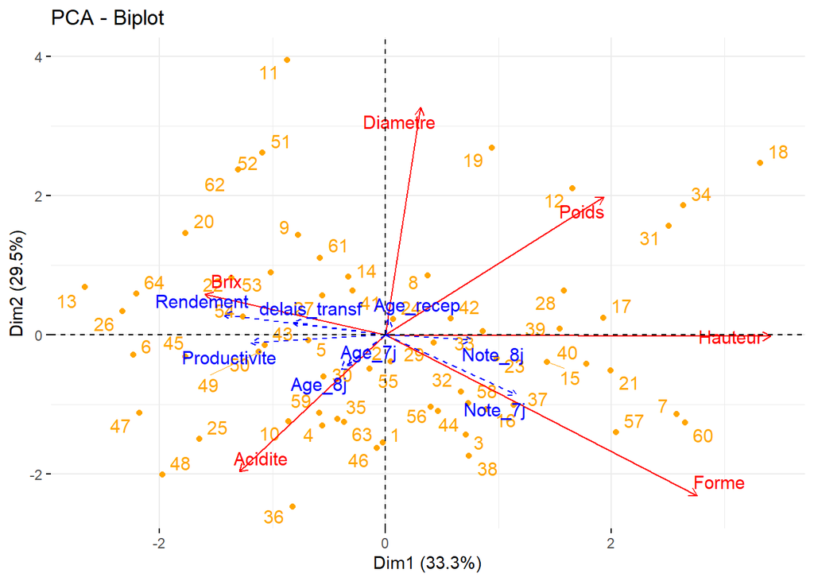

```r
fviz_pca_biplot(res.pca, repel = TRUE,
                col.var = "red", # Couleur des variables
                col.ind = "orange"  # Couleur des individus
                )
```

L’analyse du biplot sur les différentes dimensions laissent apparaître plusieurs groupes.

Ainsi sur la première dimensions on a:

- Le groupe constitué par les individus (7,21 et 60) se distingue par de fortes valeurs pour les variables `Forme`, `Hauteur` et `Note_j7` et de faibles valeurs le taux de sucre `Brix`.
- Un autre groupe représenter par les fruits (34,31,12,18,19) avec de fortes valeurs pour les variables `Diametre`, `Poids` et `Hauteur,` et de faibles valeurs pour les variables `Acidite` et `Rendement`.
- Le groupe auquel les fruits (36, 48 et 47) appartiennent on de fortes valeurs pour les variables `Acidite` et `Brix`, et de faibles valeurs pour les variables `Poids`, `Diametre`, `Hauteur` et `Note_8j`.

On peut également observé un groupe qui partage de fortes valeurs pour les variables `Rendement` et `Diametre`, et de faibles valeurs pour les variables `Forme`, `Note_7j` et `Hauteur` auquel les fruits (62, 64 et 11) appartiennent.

Pour la deuxième dimension on peu mettre en évidence :

Le groupe représenté par les individus (11, 62 et 64) qui ont des valeurs élevées pour les variables `Rendement` et `Diamètre`, et des valeurs faibles pour les variables `Forme`, `Note_7j` et `Hauteur`.

Un autre groupe avec de fortes valeurs pour les variables `Poid`, `Hauteur` et `Diamètre`, et de faibles valeurs pour les variables `Acidite` et `Rendement` s’observe également avec les fruits (19, 34, 18, 31).

Finalement nous pouvons aussi distigué Le groupe auquel les individus (36, 47 et 48) appartiennent caractérisé par de fortes valeurs pour les variables `Acidite` et `Brix`, et de faibles valeurs pour les variables `Poids`, `Diametre`, `Hauteur` et `Note_8j`.

## VI. Classification

Au vu des analyses précédentes, on a réalisé une classification ascendante hiérarchique des individus.

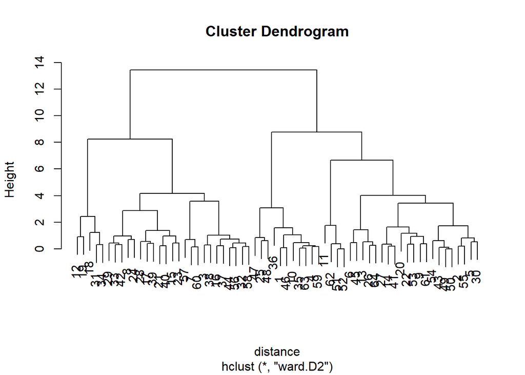

```r
#calcul de la distance
distance<-dist(res.ind$coord[,1:2])
#HCPC(res.ind$coord[,1:2], nbclust=-1)

#classification cash
classif<-hclust(distance,method="ward.D2")
plot(classif)
```

Pour obtenir une partition des fruits, nous allons regrouper les fruits dont le regroupement entraîne une perte minimale de l’inertie intra-classes. Pour cela nous utiliserons les sauts d’inertie du dendrogramme selon le nombre de classes retenu.

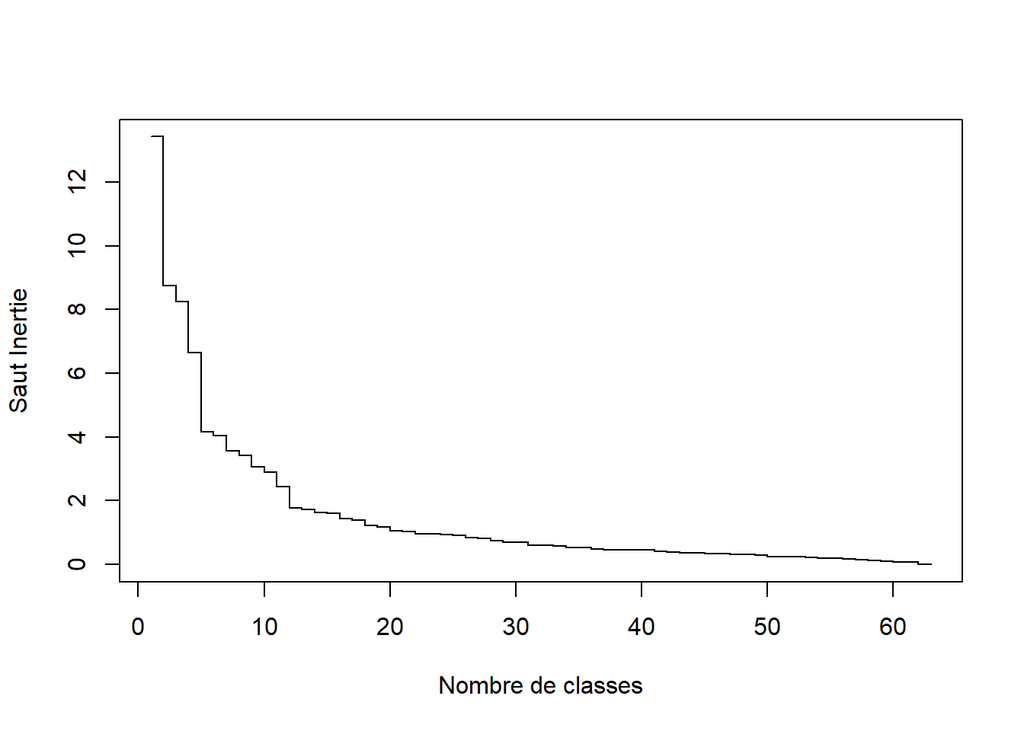

```r
# trie des inertie par ordre décroissant
saut_inert <- sort(classif$height, decreasing = TRUE)
plot(saut_inert, type = "s", xlab = "Nombre de classes", ylab = "Saut Inertie")
```

Quatre groupes ressortent de cette classification.(k=4)

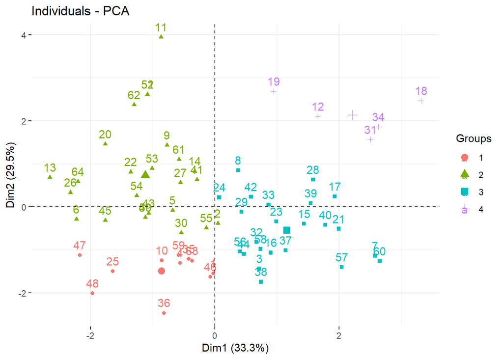

```r
#découpage en 4 groupes
groupes.cah <- cutree(classif,k=4)
#représentation des classes sur les deux premières dimensions
fviz_pca_ind(res.pca,axes=c(1,2),habillage=as.factor(groupes.cah))
```

## VII. Analyses des correspondances multiples (ACM)

Afin de faire une exploration des données qualitatives et d’appréhender des liaisons entre variables, l’outil statistique le plus pertinent serait l’ACM. Pour cela nous allons utiliser que la base sur l’année 2021 vu que les données sur celle de 2020 sont incomplètes.

L’objectif est d’identifier une typologie de fruits et de détecter les variables qui peuvent jouer sur le rendement et la productivité. Le choix des variables se justifie par : les variables qualitatives à 7jours sont choisies à la place de celles à 8 jours en raison de leur forte corrélation positive ensuite nous prendrons comme variable illustrative quantitative :`Productivité` et comme qualitative `Conf_7j`.

C’est en fonction de cette dernière que nous tenterons de faire une typologie de fruits. Pour faire l’ACM, nous passerons par les étapes suivantes :

- Choix du nombre de dimension
- Etude des individus( fruits)
- Etude des variables
- Conclusion

Notons que les données peuvent être étudiées à partir des individus, des variables et des modalités, ceci améne à se poser plusieurs types de questions relatives à ces objets de nature différentes.

```r
#création d'une base avec uniquement les données de 2021
qlNA<-select(mydata2021,Fournisseurs,Colo,Taches,Com_rec,Colo_7j,Conf_7j,Homo_7j,Carac_7j,Productivite)
#Mise en oeuvre de l'ACM
res.mca <- MCA(qlNA,  quanti.sup = 9, quali.sup=6, graph =F)
```

### 1. choix du nombre de dimensions

```r
val_propr=get_eigenvalue(res.mca)
val_propr
```

```
##        eigenvalue variance.percent cumulative.variance.percent
## Dim.1  0.38125978       15.6989320                    15.69893
## Dim.2  0.31618546       13.0194014                    28.71833
## Dim.3  0.28003091       11.5306844                    40.24902
## Dim.4  0.21681621        8.9277261                    49.17674
## Dim.5  0.18773533        7.7302781                    56.90702
## Dim.6  0.17145957        7.0601000                    63.96712
## Dim.7  0.16393699        6.7503468                    70.71747
## Dim.8  0.13905643        5.7258529                    76.44332
## Dim.9  0.11920760        4.9085483                    81.35187
## Dim.10 0.09913132        4.0818777                    85.43375
## Dim.11 0.08399379        3.4585677                    88.89232
## Dim.12 0.07544354        3.1064987                    91.99881
## Dim.13 0.05638702        2.3218184                    94.32063
## Dim.14 0.04598056        1.8933173                    96.21395
## Dim.15 0.03984629        1.6407298                    97.85468
## Dim.16 0.03415113        1.4062230                    99.26090
## Dim.17 0.01794951        0.7390973                   100.00000
```

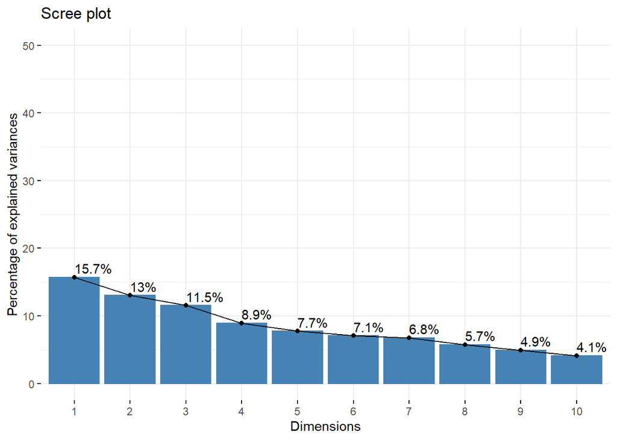

```r
#histogramme pour le coude
scree.plot=fviz_eig(res.mca,addlabels = T,ylim=c(0,50))
scree.plot
```

La décroissance des valeurs propres est un peu régulière, nous n’observons pas de décrochage flagrant donc il sera difficile de choisir le nombre d’axes graphiquement. Par contre, on sait que les trois dimensions expriment 40 % de l’inertie totale c’est à dire 40% de l’information du tableau est résumée par les trois premières dimensions donc il serait intéressant d’en retenir 3.

### 2. Analyse des résultats

### 3. Etude des individus

L’étude des individus consiste de comprendre les ressemblances entre individus du point de vue de l’ensemble des variables, à dresser une typologie des individus en se basant sur les modalités d’une variable.

Dans cette partie, le but est de représenter les individus (fruits) afin d’apprécier l’allure générale du nuage de points et de voir s’il y’a des formations de groupes. Ici on décide de choisir la coloration du fruit au jour 7 et les commentaires à la réception pour voir si on peut classer les individus en fonction de ces deux variables. Nous représenterons deux graphes où nous colorierons les individus en fonction de la variable `Colo_7j` et en fonction de la variable `Com_recep`.

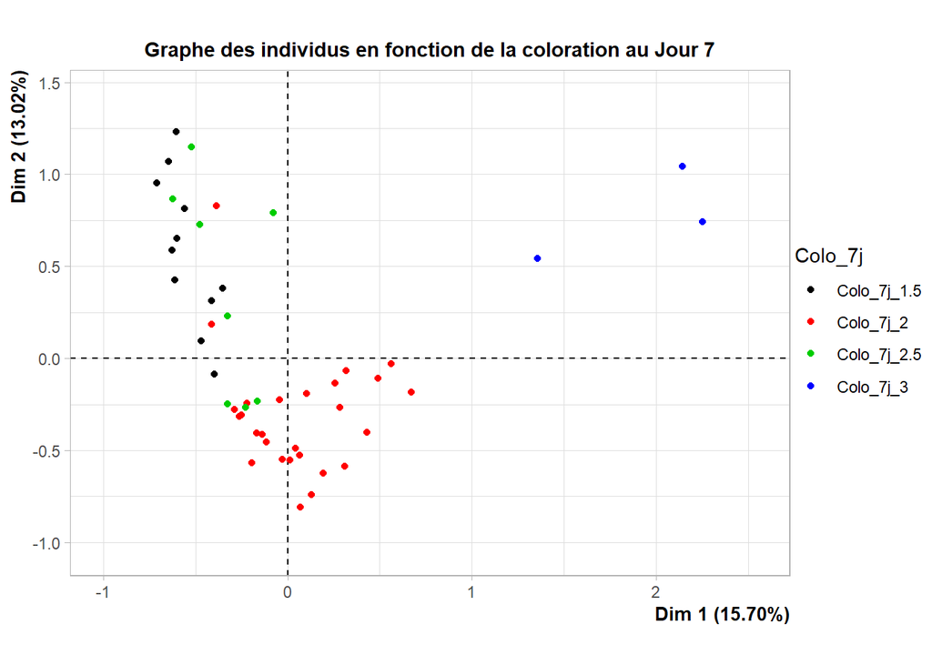

```r
plot(res.mca,invisible = c("var"),habillage=5,title = "Graphe des individus en fonction de la coloration au Jour 7", label="none")
```

Le graphe des individus (ici fruits) nous permet de voir que des groupes particuliers se dégagent en fonction de la variable `COlo_7j`.

Le interprétations et les conclusions pourront se faire après avoir fait la représentation des variables. A partir de là, nous aurons une vue globale des tendances afin de faire des typologies de fruits.

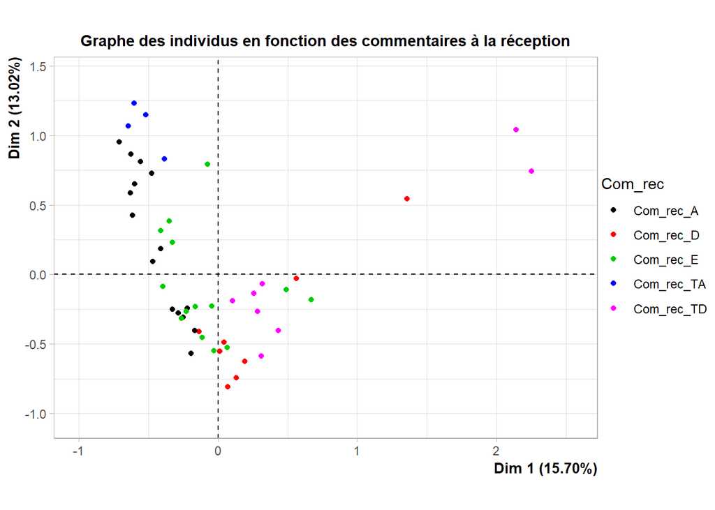

```r
plot(res.mca,invisible = c("var"),habillage=4,title = "Graphe des individus en fonction des commentaires à la réception", label="none")
```

Ces informations combinées aux analyses qui seront tirées sur le graphe des variables seront déterminantes.

### 4. Etude des variables

Les variables peuvent être représentées en calculant le rapport de corrélation entre les individus sur un axe et chacune des variables qualitatives. Si le rapport de corrélation entre la variable j et l’axe s est proche de 1 ,les individus possédant la même modalité (pour cette variable qualitative) ont des coordonnées voisines pour l’axe s.

### 5. Graphe des variables

Nous allons essayer d’identifier les variables qui contribuent le plus à la formation des trois dimensions.

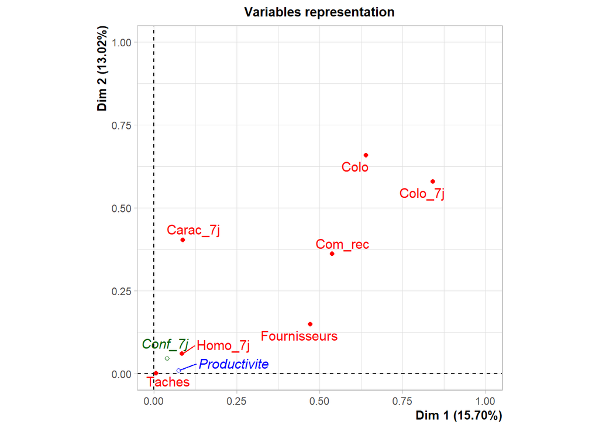

```r
# Représentation des variables aux axes 1 et 2
plot(res.mca,choix = "var")
```

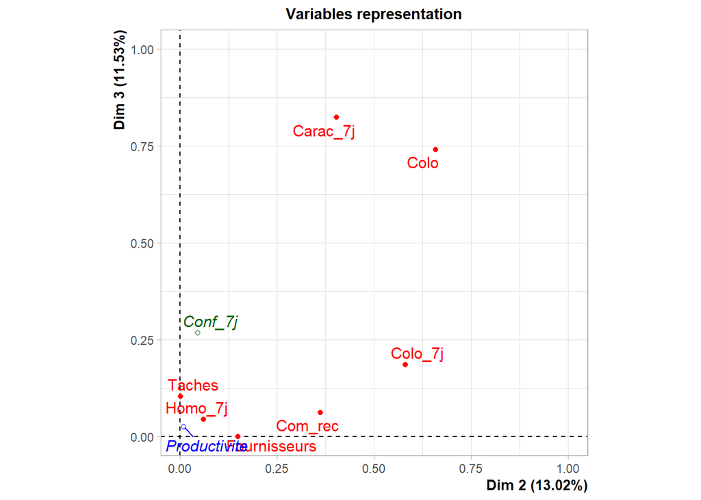

```r
# Représentation des variables aux axes 2 et 3
plot(res.mca,choix = "var",axes = 2:3)
```

Ainsi, nous voyons que la variable `Colo_7j` participe le plus à la formation de l’axe 1, la variable `Colo` à celle de l’axe 2 et enfin la variable `Carac_7`celle de l’axe 3. Cette information résume l’influence globale de toutes les modalités de chacune des variables sur la construction des axes.